# Outlier Detection and Random Forest

```python
import numpy as np
import pandas as pd
import seaborn


from sklearn.model_selection import train_test_split
from sklearn.ensemble import RandomForestClassifier
from sklearn.neighbors import LocalOutlierFactor
from sklearn.metrics import confusion_matrix
from sklearn.neighbors import NearestNeighbors

import matplotlib.pyplot as plt
```

```python
# Code here
from google.colab import drive
drive.mount('/content/drive')
```

### Part 01) Random Forest

#### Loading the dataset

Load the dataset

```python
# Load data from Dataset1.csv
pdDf = pd.read_csv('/content/drive/MyDrive/Dataset.csv')
print(pdDf.shape)
```

```
(850, 10)
```

Display the dataset, at least first ten rows of the dataset

```python
# Code here
pdDf.head(10)
```

|  | Customer Id | Age | Edu | Years Employed | Income | Card Debt | Other Debt | Defaulted | Address | DebtIncomeRatio |
| --- | --- | --- | --- | --- | --- | --- | --- | --- | --- | --- |
| 0 | 1 | 41 | 2 | 6 | 19 | 0.124 | 1.073 | 0 | NBA001 | 6.3 |
| 1 | 2 | 47 | 1 | 26 | 100 | 4.582 | 8.218 | 0 | NBA021 | 12.8 |
| 2 | 3 | 33 | 2 | 10 | 57 | 6.111 | 5.802 | 1 | NBA013 | 20.9 |
| 3 | 4 | 29 | 2 | 4 | 19 | 0.681 | 0.516 | 0 | NBA009 | 6.3 |
| 4 | 5 | 47 | 1 | 31 | 253 | 9.308 | 8.908 | 0 | NBA008 | 7.2 |
| 5 | 6 | 40 | 1 | 23 | 81 | 0.998 | 7.831 | 1 | NBA016 | 10.9 |
| 6 | 7 | 38 | 2 | 4 | 56 | 0.442 | 0.454 | 0 | NBA013 | 1.6 |
| 7 | 8 | 42 | 3 | 0 | 64 | 0.279 | 3.945 | 0 | NBA009 | 6.6 |
| 8 | 9 | 26 | 1 | 5 | 18 | 0.575 | 2.215 | 1 | NBA006 | 15.5 |
| 9 | 10 | 47 | 3 | 23 | 115 | 0.653 | 3.947 | 0 | NBA011 | 4.0 |

### Preprocessing

#### Transform the datset into features and labels. Use the *Defaulted* attribute as a label vector [05 marks]

```python
# Code here
features = pdDf.drop(['Defaulted','Address','Customer Id'], axis=1)
labels = pdDf['Defaulted']
```

```python
features.head(5)
```

|  | Age | Edu | Years Employed | Income | Card Debt | Other Debt | DebtIncomeRatio |
| --- | --- | --- | --- | --- | --- | --- | --- |
| 0 | 41 | 2 | 6 | 19 | 0.124 | 1.073 | 6.3 |
| 1 | 47 | 1 | 26 | 100 | 4.582 | 8.218 | 12.8 |
| 2 | 33 | 2 | 10 | 57 | 6.111 | 5.802 | 20.9 |
| 3 | 29 | 2 | 4 | 19 | 0.681 | 0.516 | 6.3 |
| 4 | 47 | 1 | 31 | 253 | 9.308 | 8.908 | 7.2 |

```python
labels.head(5)
```

```
0    0
1    0
2    1
3    0
4    0
Name: Defaulted, dtype: int64
```

```python
# Split the datset into train_test (70_30)
X_train, X_test, y_train, y_test = train_test_split(features, labels, test_size=0.3)
```

### Training and Evaluation

- ###### Use 10 estimators [10 Marks]

```python
# Fit the model on train data

# Create the random forest model
rf = RandomForestClassifier(n_estimators=10, max_depth=10, random_state=42)

# Fit the model on the training data
rf.fit(X_train, y_train)
```

```
RandomForestClassifier(max_depth=10, n_estimators=10, random_state=42)
```

```python
# Predict the perfromance of model on test data
y_pred = rf.predict(X_test)
```

```python
# Calculate accuracy & make the confusion matrix
accuracy = rf.score(X_test, y_test)
cm = confusion_matrix(y_test, y_pred)


# Print the accuracy score
print('Accuracy score on test data:', accuracy)

# Print the confusion matrix
print('Confusion matrix:\n', cm)
```

```
Accuracy score on test data: 0.7294117647058823
Confusion matrix:
 [[157  17]
 [ 52  29]]
```

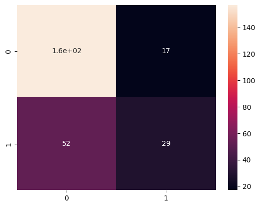

```python
# Display the confusion matrix as a heatmap as well
seaborn.heatmap(cm, annot=True)
plt.show()
```

- #### Double the estimators [10 Marks]

```python
# Fit the model on train data

# Fit the model on train data

# Create the random forest model
rf = RandomForestClassifier(n_estimators=20, max_depth=10, random_state=42)

# Fit the model on the training data
rf.fit(X_train, y_train)
```

```
RandomForestClassifier(max_depth=10, n_estimators=20, random_state=42)
```

```python
# Predict the perfromance of model on test data
y_pred = rf.predict(X_test)
```

```python
# Calculate accuracy & make the confusion matrix

accuracy = rf.score(X_test, y_test)
cm = confusion_matrix(y_test, y_pred)


# Print the accuracy score
print('Accuracy score on test data:', accuracy)

# Print the confusion matrix
print('Confusion matrix:\n', cm)
```

```
Accuracy score on test data: 0.7568627450980392
Confusion matrix:
 [[165   9]
 [ 53  28]]
```

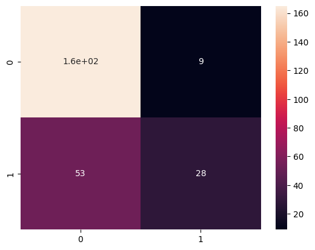

```python
# Display the confusion matrix as a heatmap as well

seaborn.heatmap(cm, annot=True)
plt.show()
```

### Part 02) Outlier Detection Part

```python
#load the provided dataset here again
pdDf = pd.read_csv('/content/drive/MyDrive/Dataset.csv')
print(pdDf.shape)
pdDf = pdDf.drop(['Address','Customer Id'], axis=1)
```

```
(850, 10)
```

```python
# Show the dataset again, i.e., dataset.head()
pdDf.head(3)
```

|  | Age | Edu | Years Employed | Income | Card Debt | Other Debt | Defaulted | DebtIncomeRatio |
| --- | --- | --- | --- | --- | --- | --- | --- | --- |
| 0 | 41 | 2 | 6 | 19 | 0.124 | 1.073 | 0 | 6.3 |
| 1 | 47 | 1 | 26 | 100 | 4.582 | 8.218 | 0 | 12.8 |
| 2 | 33 | 2 | 10 | 57 | 6.111 | 5.802 | 1 | 20.9 |

#### Visualize box plot for each attribute of the dataset. Comment on each box-plot (single line) [05 Marks]

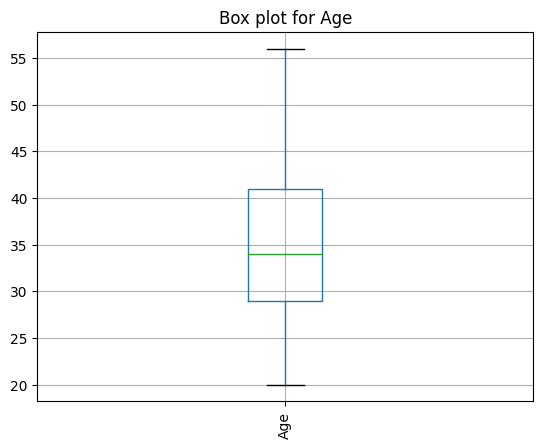

```python
# box-plot for 'Age'

pdDf.boxplot('Age')
plt.title('Box plot for Age')
plt.xticks(rotation=90)
plt.show()
```

```python
pdDf['Age'].describe().loc[['min', '25%', '50%', '75%', 'max']]
```

```
min    20.0
25%    29.0
50%    34.0
75%    41.0
max    56.0
Name: Age, dtype: float64
```

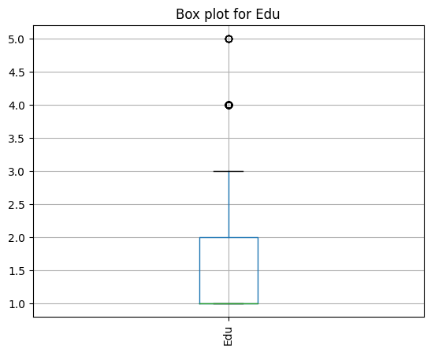

```python
# box-plot for 'Edu'
pdDf.boxplot('Edu')
plt.title('Box plot for Edu')
plt.xticks(rotation=90)
plt.show()
```

```python
pdDf['Edu'].describe().loc[['min', '25%', '50%', '75%', 'max']]
```

```
min    1.0
25%    1.0
50%    1.0
75%    2.0
max    5.0
Name: Edu, dtype: float64
```

The 5 Number summary of EDU is calculated above. There are 2 outlineres in this Column.

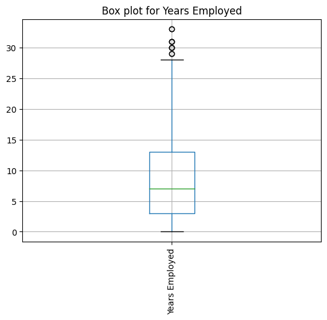

```python
# box-plot for 'Years Employed'
pdDf.boxplot('Years Employed')
plt.title('Box plot for Years Employed')
plt.xticks(rotation=90)
plt.show()
```

```python
pdDf['Years Employed'].describe().loc[['min', '25%', '50%', '75%', 'max']]
```

```
min     0.0
25%     3.0
50%     7.0
75%    13.0
max    33.0
Name: Years Employed, dtype: float64
```

The 5 Number summary of Years Employed is calculated above. There are 4 outlineres in this column. Which mean 4 people are the senior most people. The average Employment Years are from 3 - 13 years.

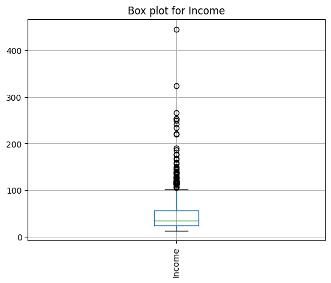

```python
# box-plot for 'Income'
pdDf.boxplot('Income')
plt.title('Box plot for Income')
plt.xticks(rotation=90)
plt.show()
```

```python
pdDf['Income'].describe().loc[['min', '25%', '50%', '75%', 'max']]
```

```
min     13.00
25%     24.00
50%     35.00
75%     55.75
max    446.00
Name: Income, dtype: float64
```

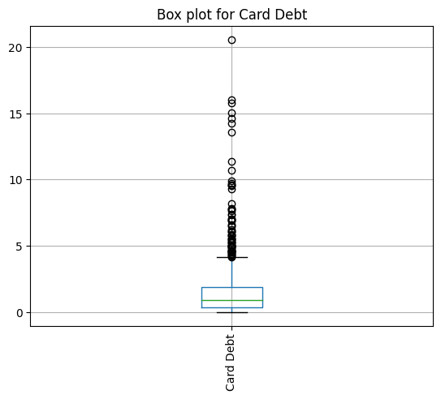

```python
# box-plot for 'Card Debt'
pdDf.boxplot('Card Debt')
plt.title('Box plot for Card Debt')
plt.xticks(rotation=90)
plt.show()
```

```python
pdDf['Card Debt'].describe().loc[['min', '25%', '50%', '75%', 'max']]
```

```
min     0.0120
25%     0.3825
50%     0.8850
75%     1.8985
max    20.5610
Name: Card Debt, dtype: float64
```

The 5 Number summary of Card Debt is calculated above. Majority of the people here have some card debt

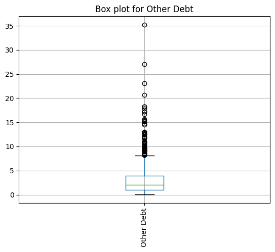

```python
# box-plot for 'Other Debt'
pdDf.boxplot('Other Debt')
plt.title('Box plot for Other Debt')
plt.xticks(rotation=90)
plt.show()
```

```python
pdDf['Other Debt'].describe().loc[['min', '25%', '50%', '75%', 'max']]
```

```
min     0.04600
25%     1.04575
50%     2.00300
75%     3.90325
max    35.19700
Name: Other Debt, dtype: float64
```

The 5 Number summary of Other Debt is calculated above. Majority of the people here have some debt which reaches till 35

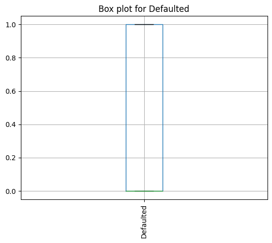

```python
# box-plot for 'Defaulted'
pdDf.boxplot('Defaulted')
plt.title('Box plot for Defaulted')
plt.xticks(rotation=90)
plt.show()
```

```python
print("Total Number of Defaulters:" , pdDf['Defaulted'].value_counts()[1])
print("Total Number of Non-Defaulters:" , pdDf['Defaulted'].value_counts()[0])

pdDf['Defaulted'].describe().loc[['min', '25%', '50%', '75%', 'max']]
```

```
Total Number of Defaulters: 277
Total Number of Non-Defaulters: 573
```

```
min    0.0
25%    0.0
50%    0.0
75%    1.0
max    1.0
Name: Defaulted, dtype: float64
```

The Total number of Defaulters in this data is 277 and non defaulters are 573.

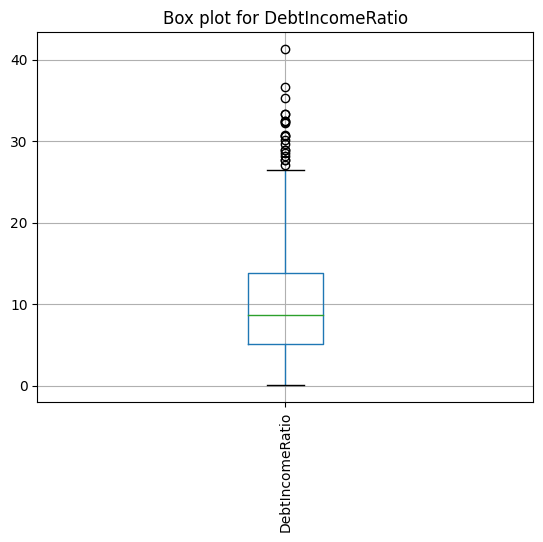

```python
# box-plot for 'DebtIncomeRatio'
pdDf.boxplot('DebtIncomeRatio')
plt.title('Box plot for DebtIncomeRatio')
plt.xticks(rotation=90)
plt.show()
```

```python
pdDf['DebtIncomeRatio'].describe().loc[['min', '25%', '50%', '75%', 'max']]
```

[output not shown]

```
min     0.1
25%     5.1
50%     8.7
75%    13.8
max    41.3
Name: DebtIncomeRatio, dtype: float64
```

The 5 Number summary of DebtIncomeRatio is calculated above. Ther are multiple outliners above 28. The average ratio is between 5.1 to 13.8.

#### Standard Deviation [10 Marks]

If certain point is some standard deviation(threshold) away from the mean it can be identified as outlier. For **Income and Card Debt**, output the list of values that are identified as outliers using optimal value of threshold.

```python
from numpy import mean
from numpy import std

# Code here
pdDf = pdDf.drop(['Defaulted'], axis=1)

# calculate the Z-score for each data point
Income_Zscore = (pdDf['Income'] - pdDf['Income'].mean()) / pdDf['Income'].std()
CardDebt_Zscore = (pdDf['Card Debt'] - pdDf['Card Debt'].mean()) / pdDf['Card Debt'].std()

# identify the outliers based on the threshold
outliers = pdDf[(np.abs(Income_Zscore) > 3) | (np.abs(CardDebt_Zscore) > 3)]

# print the list of outlier values
print(outliers[['Income', 'Card Debt']])
```

```
     Income  Card Debt
4       253      9.308
43      177      0.888
183     129     20.561
198     221     15.792
207     242      1.636
245     169      0.349
281     150     13.553
350     136     14.231
360     186      2.404
424      70     10.679
443     249      4.273
454     166      0.821
461     176     11.359
497      72     15.017
513     120     14.596
532     446     16.031
533      93      9.542
551     266      2.192
556     254      7.002
571     220      8.166
580      60      9.593
620      75      9.877
642     190      3.157
672     234      7.387
713     118      9.600
776      62      9.703
791     324      7.053
```

#### Outlier Detection using LOC (Local Outlier Factor) [10 Marks]

LOF uses density-based outlier detection to identify local outliers. An anomaly score is assigned to each sample which measures the local deviation of density of a this sample with respect to its neighbors.

```python
# Code here

def CustomLocalOutlierFactor(X, k):

    # Compute the k-distance for each data point
    nbrs = NearestNeighbors(n_neighbors=k+1).fit(X)
    distances, indices = nbrs.kneighbors(X)
    k_distances = distances[:, -1]

    # Compute the reachability distance for each pair of data points
    reachability_distances = np.zeros((len(X), k))
    for i in range(len(X)):
        for j in range(k):
            neighbor_index = indices[i, j+1]
            reachability_distances[i, j] = max(k_distances[neighbor_index], distances[i, j+1])

    # Compute the local reachability density for each data point
    lrd = k / np.sum(reachability_distances, axis=1)

    # Compute the LOF for each data point
    lof = np.zeros(len(X))
    for i in range(len(X)):
        lrd_ratios = lrd[indices[i, 1:]] / lrd[i]
        lof[i] = np.mean(lrd_ratios)

    return lof

lof = CustomLocalOutlierFactor(pdDf, k=20)

# Print the LOF scores
print(pdDf.iloc[lof.argsort()[:]])
```

```
     Age  Edu  Years Employed  Income  Card Debt  Other Debt  DebtIncomeRatio
559   26    1               1      21      0.608       0.421              4.9
370   25    1               1      20      0.472       0.868              6.7
742   25    1               1      19      0.190       1.121              6.9
248   35    4              10      45      1.040       2.785              8.5
694   26    1               2      22      0.237       1.171              6.4
..   ...  ...             ...     ...        ...         ...              ...
4     47    1              31     253      9.308       8.908              7.2
556   43    1              24     254      7.002      12.556              7.7
551   47    3              16     266      2.192       3.128              2.0
791   53    1              33     324      7.053      15.627              7.0
532   43    4              18     446     16.031      12.959              6.5

[850 rows x 7 columns]
```

- Tranform the features by scaling them to a given range(e.g. 0-1):

```python
from sklearn.preprocessing import MinMaxScaler
#Write your code here for minmax scaling

# Initialize the scaler
scaler = MinMaxScaler()

# Scale the features
scaled_features = scaler.fit_transform(pdDf)

# Convert the scaled features back to a DataFrame
df_scaled = pd.DataFrame(scaled_features, columns=pdDf.columns)
```

```python
df_scaled
```

|  | Age | Edu | Years Employed | Income | Card Debt | Other Debt | DebtIncomeRatio |
| --- | --- | --- | --- | --- | --- | --- | --- |
| 0 | 0.583333 | 0.25 | 0.181818 | 0.013857 | 0.005450 | 0.029217 | 0.150485 |
| 1 | 0.750000 | 0.00 | 0.787879 | 0.200924 | 0.222395 | 0.232483 | 0.308252 |
| 2 | 0.361111 | 0.25 | 0.303030 | 0.101617 | 0.296803 | 0.163751 | 0.504854 |
| 3 | 0.250000 | 0.25 | 0.121212 | 0.013857 | 0.032556 | 0.013371 | 0.150485 |
| 4 | 0.750000 | 0.00 | 0.939394 | 0.554273 | 0.452382 | 0.252112 | 0.172330 |
| ... | ... | ... | ... | ... | ... | ... | ... |
| 845 | 0.194444 | 0.00 | 0.151515 | 0.030023 | 0.026084 | 0.033399 | 0.162621 |
| 846 | 0.222222 | 0.25 | 0.212121 | 0.048499 | 0.016886 | 0.056186 | 0.167476 |
| 847 | 0.138889 | 0.75 | 0.000000 | 0.011547 | 0.135773 | 0.090012 | 0.808252 |
| 848 | 0.333333 | 0.00 | 0.363636 | 0.034642 | 0.005061 | 0.018492 | 0.067961 |
| 849 | 0.888889 | 0.00 | 0.484848 | 0.117783 | 0.090223 | 0.102188 | 0.206311 |

850 rows × 7 columns

- Implement LOC algorithm using sklearn. Choose the parameters that will be passed into the function:

```python
# Code here

# Initialize the LOF model
lof = LocalOutlierFactor(n_neighbors=20)

# Fit the model to the data
lof.fit(pdDf)

# Predict the outlier scores for each sample
outliers = pdDf[lof.negative_outlier_factor_ < lof.offset_]

# Print the top outliers
print(outliers)
```

```
     Age  Edu  Years Employed  Income  Card Debt  Other Debt  DebtIncomeRatio
4     47    1              31     253      9.308       8.908              7.2
43    37    5               9     177      0.888       9.555              5.9
81    30    3               0      65      3.900      15.405             29.7
175   53    1               0      27      2.754       5.049             28.9
198   47    3              16     221     15.792      23.104             17.6
207   43    1              25     242      1.636       4.656              2.6
281   50    1              30     150     13.553      35.197             32.5
360   42    4              15     186      2.404       4.292              3.6
443   51    2              31     249      4.273      15.149              7.8
497   33    1              14      72     15.017      14.719             41.3
513   54    1              25     120     14.596      17.204             26.5
532   43    4              18     446     16.031      12.959              6.5
551   47    3              16     266      2.192       3.128              2.0
556   43    1              24     254      7.002      12.556              7.7
557   46    2               9      15      0.015       0.630              4.3
571   40    3               5     220      8.166      27.034             16.0
642   42    5               6     190      3.157      11.663              7.8
672   52    4              13     234      7.387      10.631              7.7
791   53    1              33     324      7.053      15.627              7.0
```

- What value did you use for the 'n_neighbours'?

```python
# Answer
20
```

```
20
```

- Print the length of outliers returned by LOF.

```python
# Code here
# Print the length of the outliers
print("Number of outliers detected:", len(outliers))
```

```
Number of outliers detected: 19
```